# FutureLearn Cyber Security Retention Analysis

Angeline Aurel Efendy

2026-01-10

# Introduction

This report examines the implementation of the Cross-Industry Standard Process for Data Mining (CRISP-DM) on learner data from the Future Learn Cyber Security course (Run 6). Two cycles of the CRISP-DM process were conducted to identify patterns of learner engagement, retention, and dropout which are informative for course stakeholders.

The stakeholders for this analysis comprise the Future Learn platform team, course educators and learning designers, as well as educational institutions that utilize learning analytics to evaluate and enhance the quality of online courses. Engagement and retention of learners are crucial in online education, as high enrollment counts do not inherently result in excellent learning outcomes. Courses characterized by high early dropout rates may not fulfill their educational goals, despite strong initial learner engagement.

Understanding when learners disengage and the factors associated with early dropout is essential for enhancing course design. This report aims to provide practical insights into learners’ experiences of the Cyber Security course by assessing behavioral engagement data in combination with survey-based feedback, and examining how these experiences correlate with patterns of retention and disengagement.

The specific research question to be examined are:

> **“Cycle 1: What are the patterns of participant engagement and retention in the Future Learn Cyber Security course, and at which stage or week do most participants drop out?**”

> **“Cycle 2: What factors are associated with early dropout, based on learners’ stated reasons in the leaving survey (individual level), and how do weekly sentiment patterns correlate with dropout rates at the aggregate level?**”

This is of interest because identifying when learners disengage and the factors associated with early dropout, can help stakeholders improve course design and learner support. This CRISP-DM analysis is successful if it pinpoints the key dropout weeks and the main reasons/sentiment patterns linked to early dropout, or shows that dropout is evenly spread and not clearly associated with these factors.

# CRISP-DM Cycle 1 - Engagement & Retention

## Business Understanding

The stakeholders for this analysis are the Future Learn platform team and the Cyber Security course educators (and institutions using the course data for evaluation). This investigation helps them by showing where learners disengage and drop out, so they can improve on boarding, workload, and course design to increase retention. The analysis goals are to measure engagement and retention, identify the weeks with the largest drop-off, and explore reasons/sentiment patterns linked to early dropout.

## Data Understanding

This project uses learning analytics data from the Future Learn Cyber Security course (Run 6). The datasets include enrollments (learner demographics and enrollment information), step activity (logs of when learners first visited and completed learning steps), question responses (quiz performance), video statistics (video viewing behavior), and two optional feedback sources: the leaving survey (reasons for leaving) and the weekly sentiment survey (weekly experience ratings). The data are longitudinal, meaning they track learner activity over time, and several tables contain multiple rows per learner because each learner can interact with many steps, quizzes, or videos.

There are some expected data quality limitations. Survey datasets are incomplete by design because participation is optional, so many learners have missing leaving reasons or sentiment responses. Some timestamp fields may be missing for certain activities, and demographic variables may include missing values or “Unknown” entries. In addition, the raw data include non-learner accounts (e.g., educators/mentors listed in the team-members file) that must be filtered out to avoid bias when estimating engagement and retention patterns.

## Data Preparation

Data preparation was carried out using a series of scripts in the munge/ directory to ensure that the analysis was reproducible. All raw datasets were first loaded from the data/ folder, and timestamp variables in the activity logs were converted to appropriate date–time formats where required. Because the raw data include accounts belonging to course staff (such as educators and mentors), these non-learner accounts were identified using the team-members data and removed to avoid bias in engagement and retention estimates.

Learner activity data were then aggregated to the learner level. From the step activity logs, several derived variables were created, including whether a learner started the course, the total number of learning steps completed, and the last week in which any step was completed. These derived features were combined with cleaned enrolment data to produce a single record per learner. Finally, a weekly drop-off summary was created by counting the number of learners whose last completed activity occurred in each week of the course. These transformations produced clean, analysis-ready datasets that support the investigation of engagement, retention, and dropout patterns.

Key engagement and retention metrics for the Cyber Security course

| total_learners | learners_started | completion_rate | early_dropout_rate |
| --- | --- | --- | --- |
| 3171 | 2292 | 10% | 79% |

## Modelling

The retention pattern across course weeks is shown in Figure 1, which reports the proportion of learners who remain active up to each week. The curve drops sharply in the earliest weeks, indicating that disengagement is heavily concentrated at the beginning of the course. After the initial decline, the curve flattens, suggesting that learners who pass the early stage are more likely to continue. In terms of the research question, this indicates that retention does not decrease evenly over time but is instead concentrated at the beginning of the course.

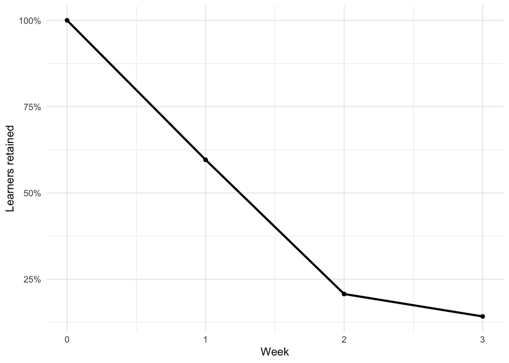

Retention curve showing the proportion of learners remaining active by week

Figure 2 summarises drop-off by identifying each learner’s last completed week. The largest bar indicates the week where disengagement is most concentrated. This provides a clear, actionable view of the “critical week(s)” that should be prioritized for course redesign or learner support. In relation to the research question, it specifically identifies the stage or week at which the most participants stop participating.

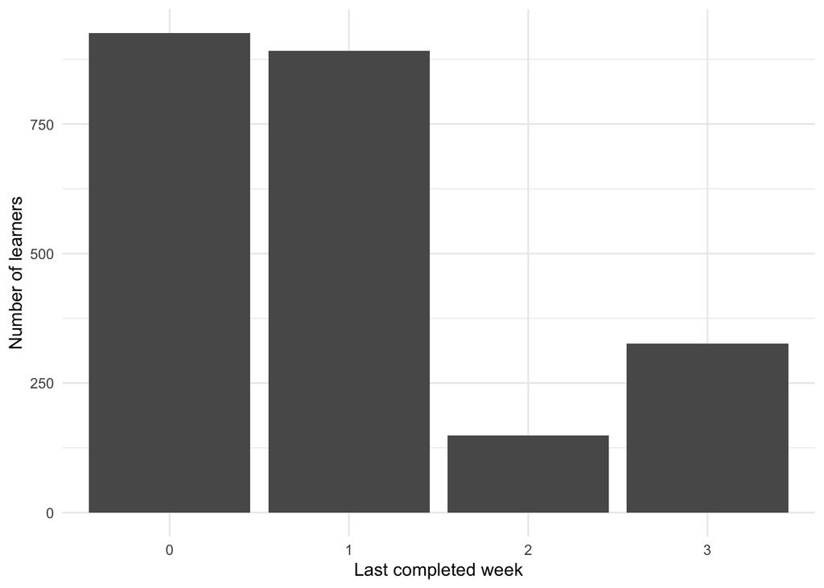

Number of learners by last completed week (drop-off distribution)

**Idea:** show the learner “flow” from *Enrolled → Started → Reached Week 2 → Reached Week 3 → Completed*  
This **is more engaging** and easier for non-technical audiences to understand.

Figure 3 presents a learner funnel that illustrates how participation decreases across key milestones. The largest losses occur at the earliest milestones, indicating that improvements to onboarding and Week 1 content may yield the greatest retention gains.In relation to the research question, this strengthens the finding that early drop-out is the dominant pattern rather than a phenomenon that occurs toward the end of the course.

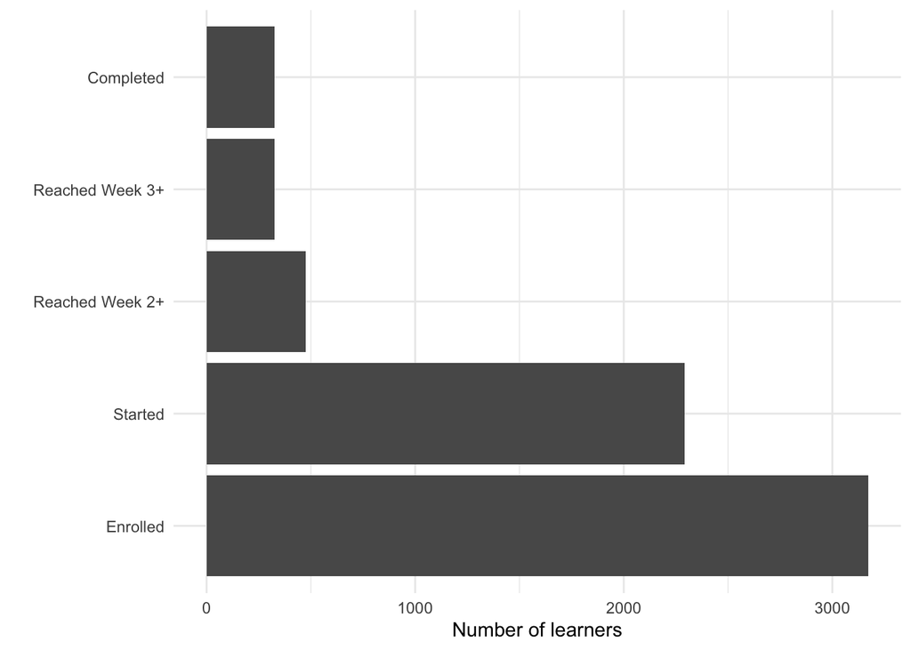

Learner funnel across course milestones

**Idea:** for each last_week, examine distribution of steps_completed.  
This shows “what engagement looks like at a given week”.

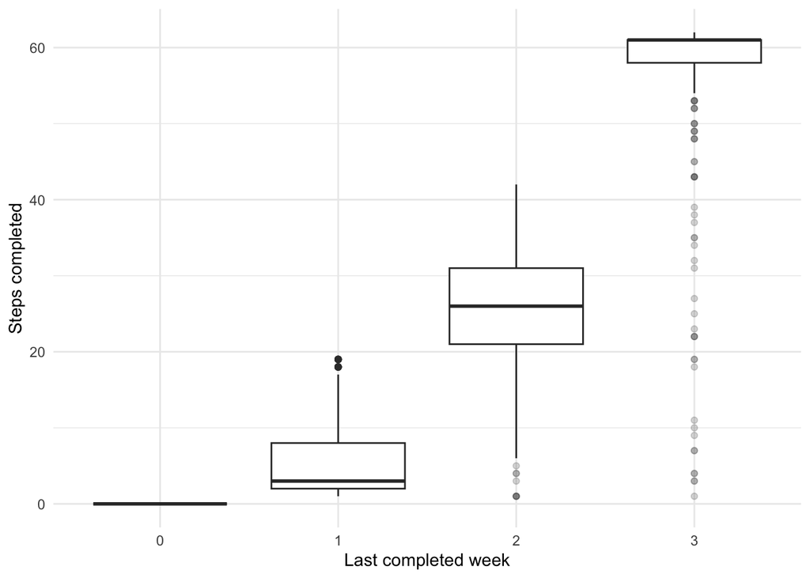

Steps completed distribution by last completed week

> The concentration of drop-off in the earliest weeks suggests that the main retention problem occurs early in the learner journey. This motivates the second CRISP-DM cycle, which explores potential explanations for early dropout using leaving survey responses (individual-level) and weekly sentiment ratings (aggregate-level).